# Analysis

### Density–Seats in Theatre

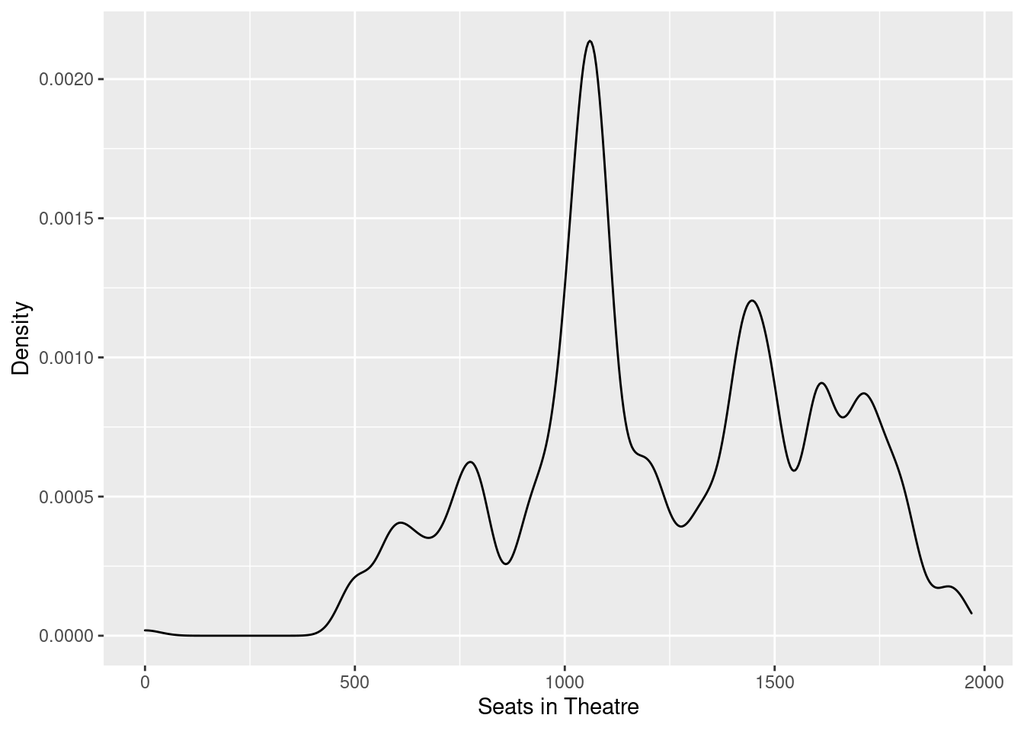

As this graph reveals, the seat capacity varies in different theatres. The size of a theatre might be a factor which influences the relationship between variables. Therefore, we mutate the theatres into different categories based on theatre size and do visualizations to further explore the relationship.

### Frequency–Weekly Gross Revenue

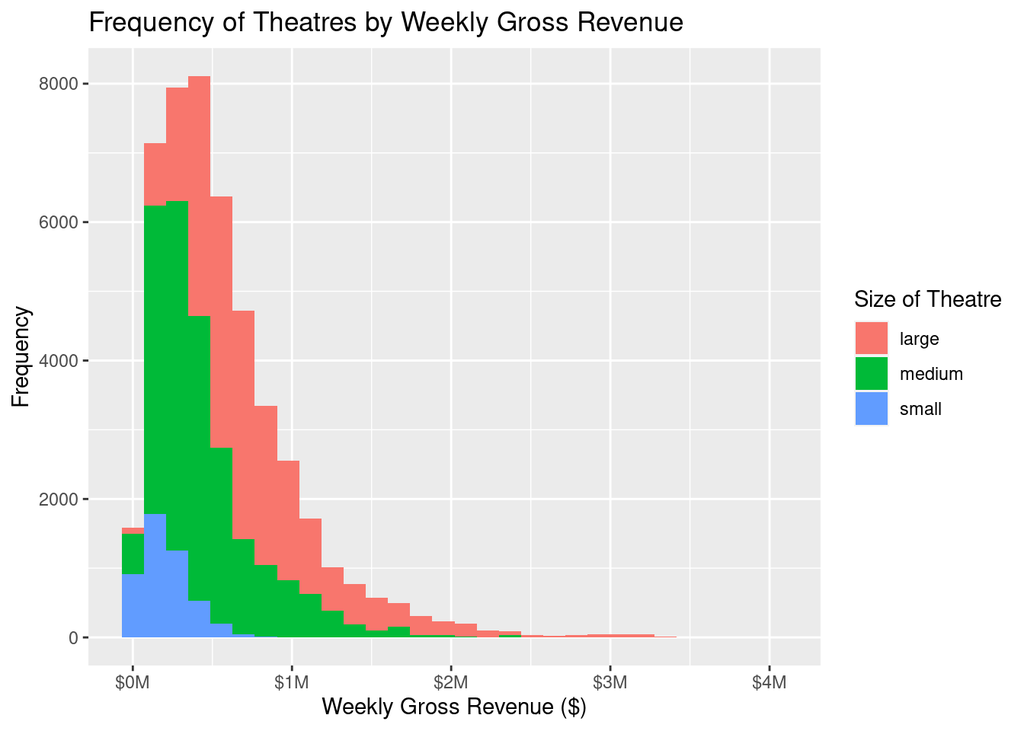

### Weekly Gross Revenue–Average Ticket Price

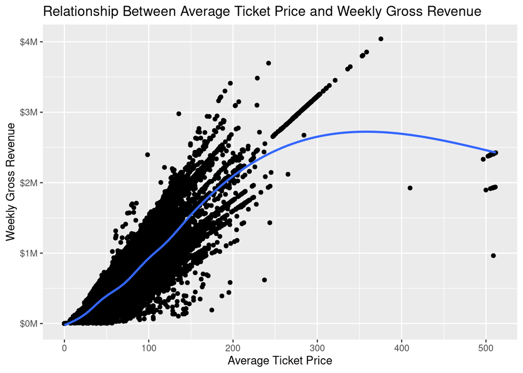

### Weekly Gross Revenue–Percentage of Seats Capacity Sold

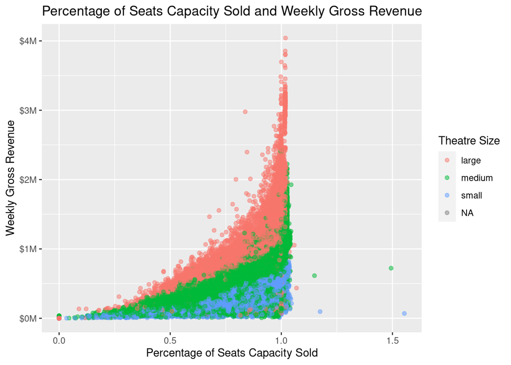

This plot reveals the fact that higher percentage of seats capacity sold leads to higher weekly gross revenue. The distribution of colors, that red is above green, and green is above blue, demonstrate that under same percentage, theatres with larger size will have higher weekly gross revenue. This is the same as we expected, since the total number of seats is higher in larger theatres.

### Weekly Gross Revenue/Average Ticket Price–Performances

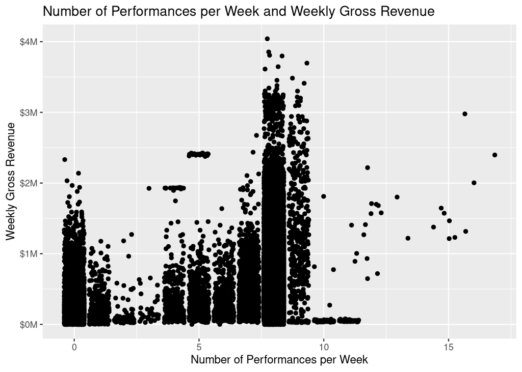

This graph shows that some of the highest weekly gross revenue appear when the number of performances is 8 or 9. However, the graph doesn’t indicate any relationship between weekly revenue and number of performances since the data are randomly disbributed without any pattern (that is, theatres with low number of performances per week can have high weekly revenue, while those with high number of performances per week may receive revenue not as high).

This is the same with average ticket price:

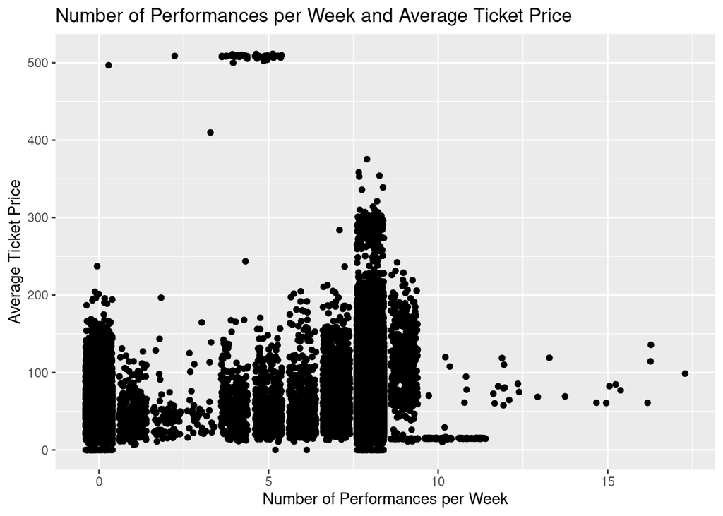

### Average Ticket Price–Week Running

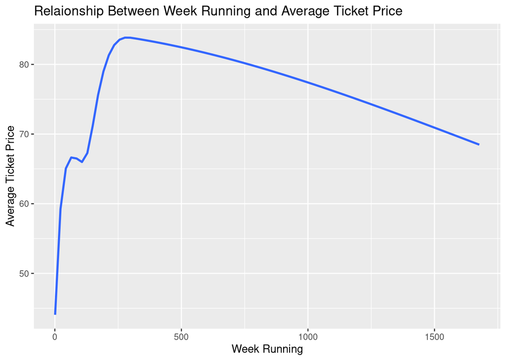

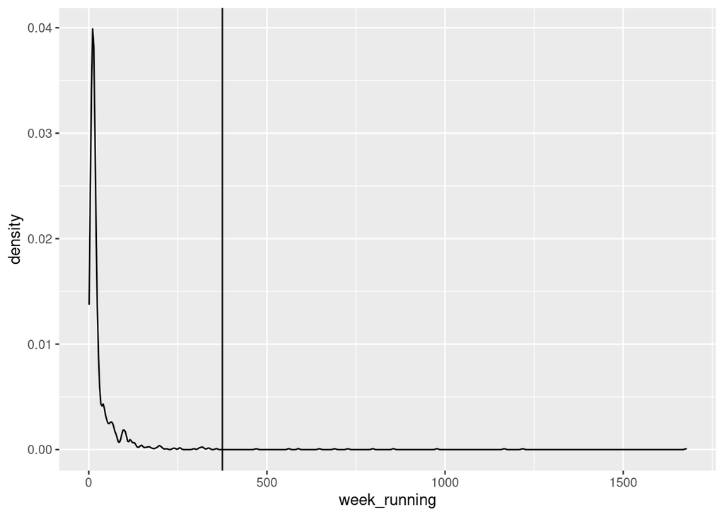

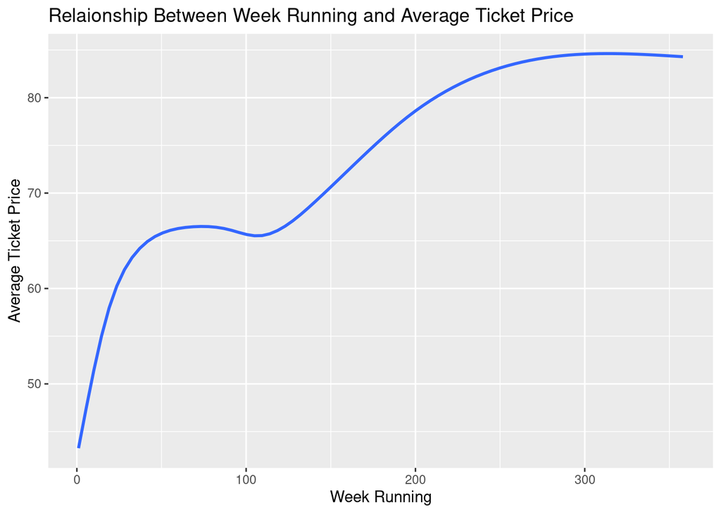

```
## # A tibble: 2 × 5
##   term        estimate std.error statistic  p.value
##   <chr>          <dbl>     <dbl>     <dbl>    <dbl>
## 1 (Intercept)   16.2      2.28        7.14 1.59e-12
## 2 x              0.230    0.0347      6.63 5.04e-11
```

### Average Ticket Price–Seat Capacity

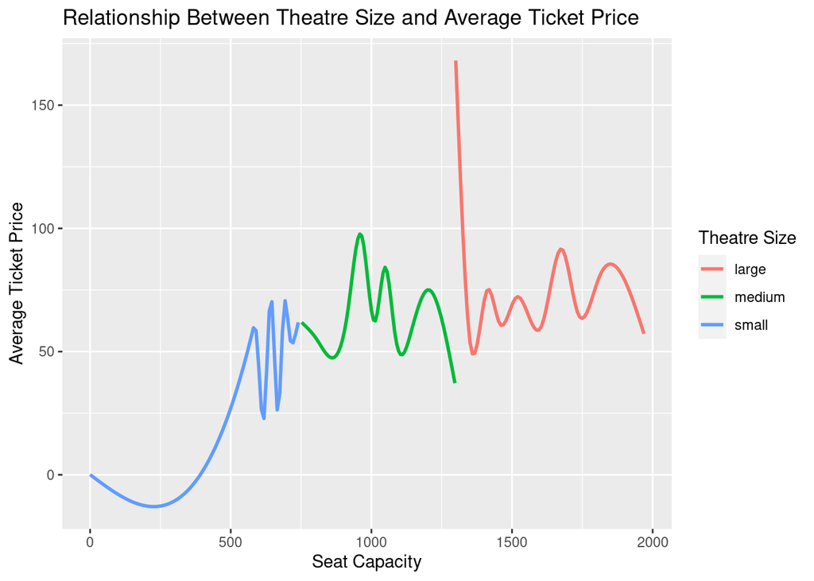

Using the function geom_smooth, all points are joint together to form smooth curves. From the graph, we can see that there is no relationship between seat capacity and average ticket price.

### Average Ticket Price–Percentage of Seats Capacity Sold

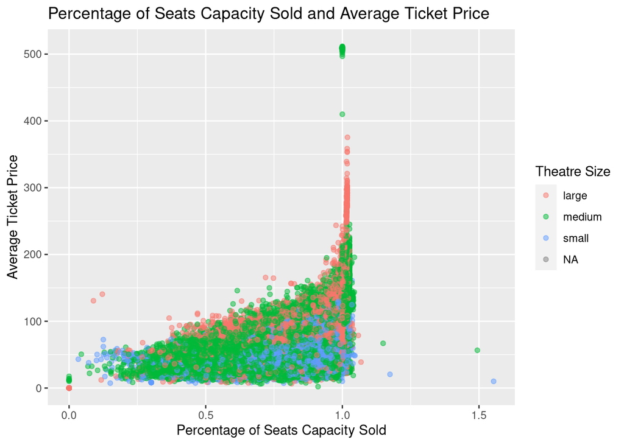

### Summary Statistics

```
## # A tibble: 1 × 4
##   min_avgtprice mean_avgtprice median_avgtprice max_avgtprice
##           <dbl>          <dbl>            <dbl>         <dbl>
## 1             0           67.9             60.2          512.
```

```
## # A tibble: 1 × 4
##   min_grosswg mean_grossw median_grossw max_grossw
##         <dbl>       <dbl>         <dbl>      <dbl>
## 1           0     574487.       470064.    4041493
```